# u04

## Shared Qs (u04)

#### Question

1. Jason drew two overlapping rectangles on a 10x10 grid.

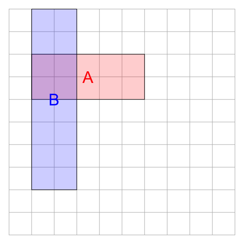

   Let’s call the red rectangle A and the blue rectangle B. Find the following areas:
   - Area covered by A = squares
   - Area covered by B = squares
   - Area covered by the intersection of A and B = squares
   - Area covered by the union of A and B = squares
   - Area covered by ONLY A (and not B) = squares
   - Area covered by ONLY B (and not A) = squares
   - Area not covered (neither A nor B) = squares

#### Solution

#### Question

2. Jason drew two overlapping rectangles on a 10x10 grid.

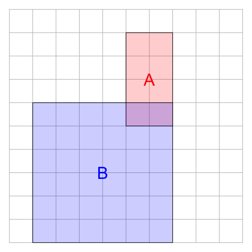

   Let’s call the red rectangle A and the blue rectangle B. Find the following areas:
   - Area covered by A = squares
   - Area covered by B = squares
   - Area covered by the intersection of A and B = squares
   - Area covered by the union of A and B = squares
   - Area covered by ONLY A (and not B) = squares
   - Area covered by ONLY B (and not A) = squares
   - Area not covered (neither A nor B) = squares

#### Solution

#### Question

3. Jason drew two overlapping rectangles on a 10x10 grid.

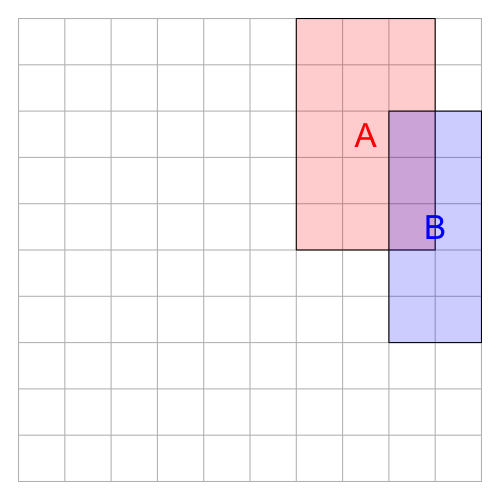

   Let’s call the red rectangle A and the blue rectangle B. Find the following areas:
   - Area covered by A = squares
   - Area covered by B = squares
   - Area covered by the intersection of A and B = squares
   - Area covered by the union of A and B = squares
   - Area covered by ONLY A (and not B) = squares
   - Area covered by ONLY B (and not A) = squares
   - Area not covered (neither A nor B) = squares

#### Solution

#### Question

4. Jason drew two overlapping rectangles on a 10x10 grid.

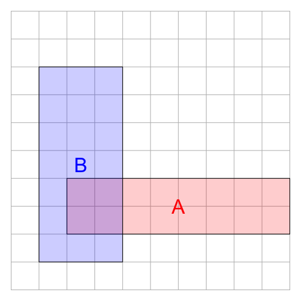

   Let’s call the red rectangle A and the blue rectangle B. Find the following areas:
   - Area covered by A = squares
   - Area covered by B = squares
   - Area covered by the intersection of A and B = squares
   - Area covered by the union of A and B = squares
   - Area covered by ONLY A (and not B) = squares
   - Area covered by ONLY B (and not A) = squares
   - Area not covered (neither A nor B) = squares

#### Solution

#### Question

5. Jason drew two overlapping rectangles on a 10x10 grid.

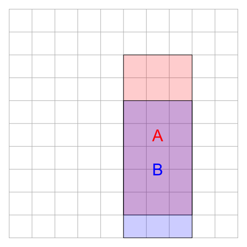

   Let’s call the red rectangle A and the blue rectangle B. Find the following areas:
   - Area covered by A = squares
   - Area covered by B = squares
   - Area covered by the intersection of A and B = squares
   - Area covered by the union of A and B = squares
   - Area covered by ONLY A (and not B) = squares
   - Area covered by ONLY B (and not A) = squares
   - Area not covered (neither A nor B) = squares

#### Solution

#### Question

6. Jason drew two overlapping rectangles on a 10x10 grid.

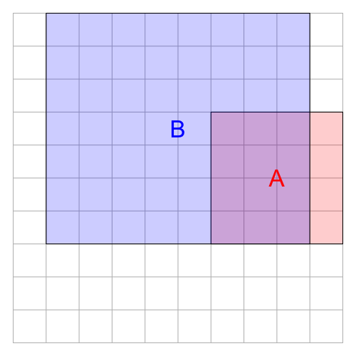

   Let’s call the red rectangle A and the blue rectangle B. Find the following areas:
   - Area covered by A = squares
   - Area covered by B = squares
   - Area covered by the intersection of A and B = squares
   - Area covered by the union of A and B = squares
   - Area covered by ONLY A (and not B) = squares
   - Area covered by ONLY B (and not A) = squares
   - Area not covered (neither A nor B) = squares

#### Solution

#### Question

7. Jason drew two overlapping rectangles on a 10x10 grid.

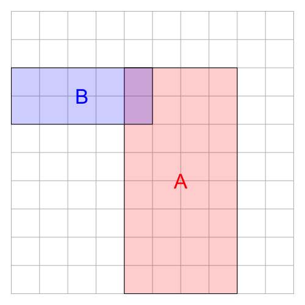

   Let’s call the red rectangle A and the blue rectangle B. Find the following areas:
   - Area covered by A = squares
   - Area covered by B = squares
   - Area covered by the intersection of A and B = squares
   - Area covered by the union of A and B = squares
   - Area covered by ONLY A (and not B) = squares
   - Area covered by ONLY B (and not A) = squares
   - Area not covered (neither A nor B) = squares

#### Solution

#### Question

8. Jason drew two overlapping rectangles on a 10x10 grid.

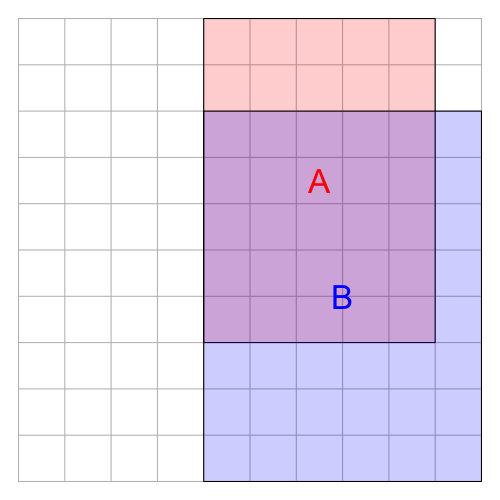

   Let’s call the red rectangle A and the blue rectangle B. Find the following areas:
   - Area covered by A = squares
   - Area covered by B = squares
   - Area covered by the intersection of A and B = squares
   - Area covered by the union of A and B = squares
   - Area covered by ONLY A (and not B) = squares
   - Area covered by ONLY B (and not A) = squares
   - Area not covered (neither A nor B) = squares

#### Solution

#### Question

9. Jason drew two overlapping rectangles on a 10x10 grid.

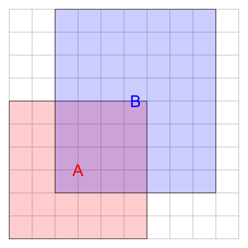

   Let’s call the red rectangle A and the blue rectangle B. Find the following areas:
   - Area covered by A = squares
   - Area covered by B = squares
   - Area covered by the intersection of A and B = squares
   - Area covered by the union of A and B = squares
   - Area covered by ONLY A (and not B) = squares
   - Area covered by ONLY B (and not A) = squares
   - Area not covered (neither A nor B) = squares

#### Solution

#### Question

10. Jason drew two overlapping rectangles on a 10x10 grid.

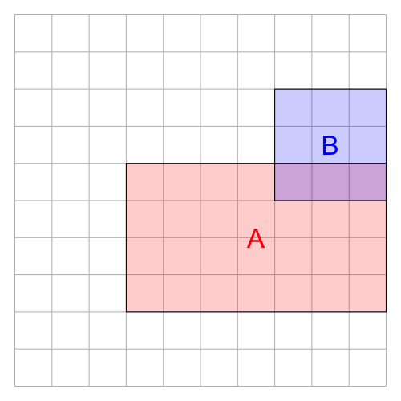

    Let’s call the red rectangle A and the blue rectangle B. Find the following areas:
    - Area covered by A = squares
    - Area covered by B = squares
    - Area covered by the intersection of A and B = squares
    - Area covered by the union of A and B = squares
    - Area covered by ONLY A (and not B) = squares
    - Area covered by ONLY B (and not A) = squares
    - Area not covered (neither A nor B) = squares

#### Solution

#### Question

11. In a school, there are two clubs: club A and club B. Students can join one club, both clubs, or neither club.
    - The number of students in at least one club is 40.
    - The total number of students in the school is 47.
    - The number of students in only club A (and not club B) is 2.
    - The number of students in club A is 25.

    Calculate the following:
    - How many students are in BOTH clubs? students
    - How many students are in neither club? students
    - How many students are only in club B (and not club A)? students
    - How many students are in club B? students

#### Solution

#### Question

12. In a school, there are two clubs: club A and club B. Students can join one club, both clubs, or neither club.
    - The number of students in only club B (and not club A) is 25.
    - The number of students in neither club is 18.
    - The number of students in both clubs (in A and B) is 23.
    - The number of students in at least one club is 67.

    Calculate the following:
    - How many students are in club B? students
    - How many students are in the school? students
    - How many students are only in club A (and not club B)? students
    - How many students are in club A? students

#### Solution

#### Question

13. In a school, there are two clubs: club A and club B. Students can join one club, both clubs, or neither club.
    - The number of students in only club B (and not club A) is 14.
    - The number of students in both clubs (in A and B) is 30.
    - The number of students in only club A (and not club B) is 27.
    - The total number of students in the school is 74.

    Calculate the following:
    - How many students are in club A? students
    - How many students are in club B? students
    - How many students are in at least one club? students
    - How many students are in neither club? students

#### Solution

#### Question

14. In a school, there are two clubs: club A and club B. Students can join one club, both clubs, or neither club.
    - The number of students in only club A (and not club B) is 14.
    - The number of students in only club B (and not club A) is 12.
    - The number of students in at least one club is 43.
    - The number of students in neither club is 9.

    Calculate the following:
    - How many students are in the school? students
    - How many students are in BOTH clubs? students
    - How many students are in club A? students
    - How many students are in club B? students

#### Solution

#### Question

15. In a school, there are two clubs: club A and club B. Students can join one club, both clubs, or neither club.
    - The total number of students in the school is 38.
    - The number of students in both clubs (in A and B) is 3.
    - The number of students in only club A (and not club B) is 17.
    - The number of students in club B is 19.

    Calculate the following:
    - How many students are in club A? students
    - How many students are only in club B (and not club A)? students
    - How many students are in at least one club? students
    - How many students are in neither club? students

#### Solution

#### Question

16. In a school, there are two clubs: club A and club B. Students can join one club, both clubs, or neither club.
    - The number of students in only club A (and not club B) is 5.
    - The total number of students in the school is 64.
    - The number of students in both clubs (in A and B) is 11.
    - The number of students in neither club is 30.

    Calculate the following:
    - How many students are in club A? students
    - How many students are in at least one club? students
    - How many students are only in club B (and not club A)? students
    - How many students are in club B? students

#### Solution

#### Question

17. In a school, there are two clubs: club A and club B. Students can join one club, both clubs, or neither club.
    - The number of students in club A is 29.
    - The total number of students in the school is 52.
    - The number of students in club B is 20.
    - The number of students in only club A (and not club B) is 27.

    Calculate the following:
    - How many students are in BOTH clubs? students
    - How many students are only in club B (and not club A)? students
    - How many students are in at least one club? students
    - How many students are in neither club? students

#### Solution

#### Question

18. In a school, there are two clubs: club A and club B. Students can join one club, both clubs, or neither club.
    - The number of students in club A is 40.
    - The total number of students in the school is 53.
    - The number of students in both clubs (in A and B) is 21.
    - The number of students in only club B (and not club A) is 10.

    Calculate the following:
    - How many students are only in club A (and not club B)? students
    - How many students are in club B? students
    - How many students are in at least one club? students
    - How many students are in neither club? students

#### Solution

#### Question

19. In a school, there are two clubs: club A and club B. Students can join one club, both clubs, or neither club.
    - The number of students in club B is 20.
    - The number of students in only club A (and not club B) is 8.
    - The number of students in both clubs (in A and B) is 2.
    - The total number of students in the school is 52.

    Calculate the following:
    - How many students are in club A? students
    - How many students are only in club B (and not club A)? students
    - How many students are in at least one club? students
    - How many students are in neither club? students

#### Solution

#### Question

20. In a school, there are two clubs: club A and club B. Students can join one club, both clubs, or neither club.
    - The number of students in club B is 24.
    - The number of students in only club A (and not club B) is 25.
    - The number of students in both clubs (in A and B) is 14.
    - The total number of students in the school is 64.

    Calculate the following:
    - How many students are in club A? students
    - How many students are only in club B (and not club A)? students
    - How many students are in at least one club? students
    - How many students are in neither club? students

#### Solution

#### Question

21. In symbolic logic, we often use the following symbols for [NOT](https://en.wikipedia.org/wiki/Negation), [AND](https://en.wikipedia.org/wiki/Logical_conjunction), and [OR](https://en.wikipedia.org/wiki/Logical_disjunction):

    $$\neg ~=~ \text{not}$$
    $$\cap ~=~ \text{and} ~=~ \text{intersection}$$
    $$\cup ~=~ \text{or} ~=~ \text{union}$$

    In this case (and almost always), [unary operators](https://en.wikipedia.org/wiki/Unary_operation) (like $\neg$) have higher [precedence](https://en.wikipedia.org/wiki/Order_of_operations) than [binary operators](https://en.wikipedia.org/wiki/Arity) (like $\cup$ and $\cap$).

    You are given the following probabilities (regarding events $A$ and $B$).
    - $P(\neg A\cap B)=0.3$
    - $P(A\cup B)=0.61$
    - $P(A\cap B)=0.14$

    Calculate the following:
    - $P(B)=$ students
    - $P(A\cap \neg B)=$ students
    - $P(\neg A\cap \neg B)=$ students
    - $P(\neg B)$ students
    - $P(A)=$ students
    - $P(\neg A)$ students

## Optional metaphorical context

    Imagine getting blindfolded and throwing darts at a board far away on a gusty day. On that board are two overlapping circles: circle A and circle B. If you miss the board completely, the throw does not count, and you try again. If you hit circle A, that counts as event $A$. If you miss circle A (but hit the board), that counts as $\neg A$. The probability that you hit circle A will depend on the proportion of the board’s area taken up by circle A.

    $$P(A) ~=~ \frac{\text{area of circle A}}{\text{area of board}}$$
    $$P(\neg A) ~=~ \frac{\text{area of board} ~~-~~ \text{area of circle A}}{\text{area of board}}$$

#### Solution

#### Question

22. In symbolic logic, we often use the following symbols for [NOT](https://en.wikipedia.org/wiki/Negation), [AND](https://en.wikipedia.org/wiki/Logical_conjunction), and [OR](https://en.wikipedia.org/wiki/Logical_disjunction):

    $$\neg ~=~ \text{not}$$
    $$\cap ~=~ \text{and} ~=~ \text{intersection}$$
    $$\cup ~=~ \text{or} ~=~ \text{union}$$

    In this case (and almost always), [unary operators](https://en.wikipedia.org/wiki/Unary_operation) (like $\neg$) have higher [precedence](https://en.wikipedia.org/wiki/Order_of_operations) than [binary operators](https://en.wikipedia.org/wiki/Arity) (like $\cup$ and $\cap$).

    You are given the following probabilities (regarding events $A$ and $B$).
    - $P(A)=0.61$
    - $P(A\cap B)=0.4$
    - $P(A\cup B)=0.88$

    Calculate the following:
    - $P(A\cap \neg B)=$ students
    - $P(\neg A\cap B)=$ students
    - $P(\neg A\cap \neg B)=$ students
    - $P(\neg A)$ students
    - $P(B)=$ students
    - $P(\neg B)$ students

## Optional metaphorical context

    Imagine getting blindfolded and throwing darts at a board far away on a gusty day. On that board are two overlapping circles: circle A and circle B. If you miss the board completely, the throw does not count, and you try again. If you hit circle A, that counts as event $A$. If you miss circle A (but hit the board), that counts as $\neg A$. The probability that you hit circle A will depend on the proportion of the board’s area taken up by circle A.

    $$P(A) ~=~ \frac{\text{area of circle A}}{\text{area of board}}$$
    $$P(\neg A) ~=~ \frac{\text{area of board} ~~-~~ \text{area of circle A}}{\text{area of board}}$$

#### Solution

#### Question

23. In symbolic logic, we often use the following symbols for [NOT](https://en.wikipedia.org/wiki/Negation), [AND](https://en.wikipedia.org/wiki/Logical_conjunction), and [OR](https://en.wikipedia.org/wiki/Logical_disjunction):

    $$\neg ~=~ \text{not}$$
    $$\cap ~=~ \text{and} ~=~ \text{intersection}$$
    $$\cup ~=~ \text{or} ~=~ \text{union}$$

    In this case (and almost always), [unary operators](https://en.wikipedia.org/wiki/Unary_operation) (like $\neg$) have higher [precedence](https://en.wikipedia.org/wiki/Order_of_operations) than [binary operators](https://en.wikipedia.org/wiki/Arity) (like $\cup$ and $\cap$).

    You are given the following probabilities (regarding events $A$ and $B$).
    - $P(\neg A\cap B)=0.22$
    - $P(B)=0.57$
    - $P(A\cap \neg B)=0.39$

    Calculate the following:
    - $P(A\cap B)=$ students
    - $P(A\cup B)=$ students
    - $P(\neg A\cap \neg B)=$ students
    - $P(\neg B)$ students
    - $P(A)=$ students
    - $P(\neg A)$ students

## Optional metaphorical context

    Imagine getting blindfolded and throwing darts at a board far away on a gusty day. On that board are two overlapping circles: circle A and circle B. If you miss the board completely, the throw does not count, and you try again. If you hit circle A, that counts as event $A$. If you miss circle A (but hit the board), that counts as $\neg A$. The probability that you hit circle A will depend on the proportion of the board’s area taken up by circle A.

    $$P(A) ~=~ \frac{\text{area of circle A}}{\text{area of board}}$$
    $$P(\neg A) ~=~ \frac{\text{area of board} ~~-~~ \text{area of circle A}}{\text{area of board}}$$

#### Solution

#### Question

24. In symbolic logic, we often use the following symbols for [NOT](https://en.wikipedia.org/wiki/Negation), [AND](https://en.wikipedia.org/wiki/Logical_conjunction), and [OR](https://en.wikipedia.org/wiki/Logical_disjunction):

    $$\neg ~=~ \text{not}$$
    $$\cap ~=~ \text{and} ~=~ \text{intersection}$$
    $$\cup ~=~ \text{or} ~=~ \text{union}$$

    In this case (and almost always), [unary operators](https://en.wikipedia.org/wiki/Unary_operation) (like $\neg$) have higher [precedence](https://en.wikipedia.org/wiki/Order_of_operations) than [binary operators](https://en.wikipedia.org/wiki/Arity) (like $\cup$ and $\cap$).

    You are given the following probabilities (regarding events $A$ and $B$).
    - $P(A\cup B)=0.62$
    - $P(B)=0.33$
    - $P(A\cap B)=0.19$

    Calculate the following:
    - $P(\neg A\cap B)=$ students
    - $P(A\cap \neg B)=$ students
    - $P(\neg A\cap \neg B)=$ students
    - $P(\neg B)$ students
    - $P(A)=$ students
    - $P(\neg A)$ students

## Optional metaphorical context

    Imagine getting blindfolded and throwing darts at a board far away on a gusty day. On that board are two overlapping circles: circle A and circle B. If you miss the board completely, the throw does not count, and you try again. If you hit circle A, that counts as event $A$. If you miss circle A (but hit the board), that counts as $\neg A$. The probability that you hit circle A will depend on the proportion of the board’s area taken up by circle A.

    $$P(A) ~=~ \frac{\text{area of circle A}}{\text{area of board}}$$
    $$P(\neg A) ~=~ \frac{\text{area of board} ~~-~~ \text{area of circle A}}{\text{area of board}}$$

#### Solution

#### Question

25. In symbolic logic, we often use the following symbols for [NOT](https://en.wikipedia.org/wiki/Negation), [AND](https://en.wikipedia.org/wiki/Logical_conjunction), and [OR](https://en.wikipedia.org/wiki/Logical_disjunction):

    $$\neg ~=~ \text{not}$$
    $$\cap ~=~ \text{and} ~=~ \text{intersection}$$
    $$\cup ~=~ \text{or} ~=~ \text{union}$$

    In this case (and almost always), [unary operators](https://en.wikipedia.org/wiki/Unary_operation) (like $\neg$) have higher [precedence](https://en.wikipedia.org/wiki/Order_of_operations) than [binary operators](https://en.wikipedia.org/wiki/Arity) (like $\cup$ and $\cap$).

    You are given the following probabilities (regarding events $A$ and $B$).
    - $P(A)=0.42$
    - $P(A\cup B)=0.78$
    - $P(A\cap \neg B)=0.15$

    Calculate the following:
    - $P(A\cap B)=$ students
    - $P(\neg A\cap B)=$ students
    - $P(\neg A\cap \neg B)=$ students
    - $P(\neg A)$ students
    - $P(B)=$ students
    - $P(\neg B)$ students

## Optional metaphorical context

    Imagine getting blindfolded and throwing darts at a board far away on a gusty day. On that board are two overlapping circles: circle A and circle B. If you miss the board completely, the throw does not count, and you try again. If you hit circle A, that counts as event $A$. If you miss circle A (but hit the board), that counts as $\neg A$. The probability that you hit circle A will depend on the proportion of the board’s area taken up by circle A.

    $$P(A) ~=~ \frac{\text{area of circle A}}{\text{area of board}}$$
    $$P(\neg A) ~=~ \frac{\text{area of board} ~~-~~ \text{area of circle A}}{\text{area of board}}$$

#### Solution

#### Question

26. In symbolic logic, we often use the following symbols for [NOT](https://en.wikipedia.org/wiki/Negation), [AND](https://en.wikipedia.org/wiki/Logical_conjunction), and [OR](https://en.wikipedia.org/wiki/Logical_disjunction):

    $$\neg ~=~ \text{not}$$
    $$\cap ~=~ \text{and} ~=~ \text{intersection}$$
    $$\cup ~=~ \text{or} ~=~ \text{union}$$

    In this case (and almost always), [unary operators](https://en.wikipedia.org/wiki/Unary_operation) (like $\neg$) have higher [precedence](https://en.wikipedia.org/wiki/Order_of_operations) than [binary operators](https://en.wikipedia.org/wiki/Arity) (like $\cup$ and $\cap$).

    You are given the following probabilities (regarding events $A$ and $B$).
    - $P(A\cap B)=0.4$
    - $P(A\cap \neg B)=0.25$
    - $P(B)=0.56$

    Calculate the following:
    - $P(A)=$ students
    - $P(\neg A\cap B)=$ students
    - $P(A\cup B)=$ students
    - $P(\neg A\cap \neg B)=$ students
    - $P(\neg A)$ students
    - $P(\neg B)$ students

## Optional metaphorical context

    Imagine getting blindfolded and throwing darts at a board far away on a gusty day. On that board are two overlapping circles: circle A and circle B. If you miss the board completely, the throw does not count, and you try again. If you hit circle A, that counts as event $A$. If you miss circle A (but hit the board), that counts as $\neg A$. The probability that you hit circle A will depend on the proportion of the board’s area taken up by circle A.

    $$P(A) ~=~ \frac{\text{area of circle A}}{\text{area of board}}$$
    $$P(\neg A) ~=~ \frac{\text{area of board} ~~-~~ \text{area of circle A}}{\text{area of board}}$$

#### Solution

#### Question

27. In symbolic logic, we often use the following symbols for [NOT](https://en.wikipedia.org/wiki/Negation), [AND](https://en.wikipedia.org/wiki/Logical_conjunction), and [OR](https://en.wikipedia.org/wiki/Logical_disjunction):

    $$\neg ~=~ \text{not}$$
    $$\cap ~=~ \text{and} ~=~ \text{intersection}$$
    $$\cup ~=~ \text{or} ~=~ \text{union}$$

    In this case (and almost always), [unary operators](https://en.wikipedia.org/wiki/Unary_operation) (like $\neg$) have higher [precedence](https://en.wikipedia.org/wiki/Order_of_operations) than [binary operators](https://en.wikipedia.org/wiki/Arity) (like $\cup$ and $\cap$).

    You are given the following probabilities (regarding events $A$ and $B$).
    - $P(A)=0.45$
    - $P(A\cap B)=0.21$
    - $P(A\cup B)=0.58$

    Calculate the following:
    - $P(A\cap \neg B)=$ students
    - $P(\neg A\cap B)=$ students
    - $P(\neg A\cap \neg B)=$ students
    - $P(\neg A)$ students
    - $P(B)=$ students
    - $P(\neg B)$ students

## Optional metaphorical context

    Imagine getting blindfolded and throwing darts at a board far away on a gusty day. On that board are two overlapping circles: circle A and circle B. If you miss the board completely, the throw does not count, and you try again. If you hit circle A, that counts as event $A$. If you miss circle A (but hit the board), that counts as $\neg A$. The probability that you hit circle A will depend on the proportion of the board’s area taken up by circle A.

    $$P(A) ~=~ \frac{\text{area of circle A}}{\text{area of board}}$$
    $$P(\neg A) ~=~ \frac{\text{area of board} ~~-~~ \text{area of circle A}}{\text{area of board}}$$

#### Solution

#### Question

28. In symbolic logic, we often use the following symbols for [NOT](https://en.wikipedia.org/wiki/Negation), [AND](https://en.wikipedia.org/wiki/Logical_conjunction), and [OR](https://en.wikipedia.org/wiki/Logical_disjunction):

    $$\neg ~=~ \text{not}$$
    $$\cap ~=~ \text{and} ~=~ \text{intersection}$$
    $$\cup ~=~ \text{or} ~=~ \text{union}$$

    In this case (and almost always), [unary operators](https://en.wikipedia.org/wiki/Unary_operation) (like $\neg$) have higher [precedence](https://en.wikipedia.org/wiki/Order_of_operations) than [binary operators](https://en.wikipedia.org/wiki/Arity) (like $\cup$ and $\cap$).

    You are given the following probabilities (regarding events $A$ and $B$).
    - $P(\neg A\cap B)=0.29$
    - $P(A)=0.38$
    - $P(A\cap \neg B)=0.25$

    Calculate the following:
    - $P(A\cap B)=$ students
    - $P(B)=$ students
    - $P(A\cup B)=$ students
    - $P(\neg A\cap \neg B)=$ students
    - $P(\neg A)$ students
    - $P(\neg B)$ students

## Optional metaphorical context

    Imagine getting blindfolded and throwing darts at a board far away on a gusty day. On that board are two overlapping circles: circle A and circle B. If you miss the board completely, the throw does not count, and you try again. If you hit circle A, that counts as event $A$. If you miss circle A (but hit the board), that counts as $\neg A$. The probability that you hit circle A will depend on the proportion of the board’s area taken up by circle A.

    $$P(A) ~=~ \frac{\text{area of circle A}}{\text{area of board}}$$
    $$P(\neg A) ~=~ \frac{\text{area of board} ~~-~~ \text{area of circle A}}{\text{area of board}}$$

#### Solution

#### Question

29. In symbolic logic, we often use the following symbols for [NOT](https://en.wikipedia.org/wiki/Negation), [AND](https://en.wikipedia.org/wiki/Logical_conjunction), and [OR](https://en.wikipedia.org/wiki/Logical_disjunction):

    $$\neg ~=~ \text{not}$$
    $$\cap ~=~ \text{and} ~=~ \text{intersection}$$
    $$\cup ~=~ \text{or} ~=~ \text{union}$$

    In this case (and almost always), [unary operators](https://en.wikipedia.org/wiki/Unary_operation) (like $\neg$) have higher [precedence](https://en.wikipedia.org/wiki/Order_of_operations) than [binary operators](https://en.wikipedia.org/wiki/Arity) (like $\cup$ and $\cap$).

    You are given the following probabilities (regarding events $A$ and $B$).
    - $P(A)=0.38$
    - $P(B)=0.34$
    - $P(A\cap \neg B)=0.14$

    Calculate the following:
    - $P(A\cap B)=$ students
    - $P(\neg A\cap B)=$ students
    - $P(A\cup B)=$ students
    - $P(\neg A\cap \neg B)=$ students
    - $P(\neg A)$ students
    - $P(\neg B)$ students

## Optional metaphorical context

    Imagine getting blindfolded and throwing darts at a board far away on a gusty day. On that board are two overlapping circles: circle A and circle B. If you miss the board completely, the throw does not count, and you try again. If you hit circle A, that counts as event $A$. If you miss circle A (but hit the board), that counts as $\neg A$. The probability that you hit circle A will depend on the proportion of the board’s area taken up by circle A.

    $$P(A) ~=~ \frac{\text{area of circle A}}{\text{area of board}}$$
    $$P(\neg A) ~=~ \frac{\text{area of board} ~~-~~ \text{area of circle A}}{\text{area of board}}$$

#### Solution

#### Question

30. In symbolic logic, we often use the following symbols for [NOT](https://en.wikipedia.org/wiki/Negation), [AND](https://en.wikipedia.org/wiki/Logical_conjunction), and [OR](https://en.wikipedia.org/wiki/Logical_disjunction):

    $$\neg ~=~ \text{not}$$
    $$\cap ~=~ \text{and} ~=~ \text{intersection}$$
    $$\cup ~=~ \text{or} ~=~ \text{union}$$

    In this case (and almost always), [unary operators](https://en.wikipedia.org/wiki/Unary_operation) (like $\neg$) have higher [precedence](https://en.wikipedia.org/wiki/Order_of_operations) than [binary operators](https://en.wikipedia.org/wiki/Arity) (like $\cup$ and $\cap$).

    You are given the following probabilities (regarding events $A$ and $B$).
    - $P(B)=0.49$
    - $P(A\cap \neg B)=0.27$
    - $P(A\cap B)=0.21$

    Calculate the following:
    - $P(A)=$ students
    - $P(\neg A\cap B)=$ students
    - $P(A\cup B)=$ students
    - $P(\neg A\cap \neg B)=$ students
    - $P(\neg A)$ students
    - $P(\neg B)$ students

## Optional metaphorical context

    Imagine getting blindfolded and throwing darts at a board far away on a gusty day. On that board are two overlapping circles: circle A and circle B. If you miss the board completely, the throw does not count, and you try again. If you hit circle A, that counts as event $A$. If you miss circle A (but hit the board), that counts as $\neg A$. The probability that you hit circle A will depend on the proportion of the board’s area taken up by circle A.

    $$P(A) ~=~ \frac{\text{area of circle A}}{\text{area of board}}$$
    $$P(\neg A) ~=~ \frac{\text{area of board} ~~-~~ \text{area of circle A}}{\text{area of board}}$$

#### Solution

#### Question

31. - Events $A$ and $B$ are [mutually exclusive](https://en.wikipedia.org/wiki/Mutual_exclusivity) if and only if $P(A \cap B)=0$.
    - Events $A$ and $B$ are independent if and only if $P(A \cap B)=P(A)\cdot P(B)$.

    Consider the following:

    $$P(A)=0.16$$

    $$P(B)=0.25$$

    $$P(A \cup B)=0.37$$

    Are events $A$ and $B$ independent, mutually exclusive, or neither?
    1. Independent
    2. Mutually exclusive
    3. Neither

#### Solution

#### Question

32. - Events $A$ and $B$ are [mutually exclusive](https://en.wikipedia.org/wiki/Mutual_exclusivity) if and only if $P(A \cap B)=0$.
    - Events $A$ and $B$ are independent if and only if $P(A \cap B)=P(A)\cdot P(B)$.

    Consider the following:

    $$P(A)=0.38$$

    $$P(B)=0.11$$

    $$P(A \cup B)=0.4671$$

    Are events $A$ and $B$ independent, mutually exclusive, or neither?
    1. Independent
    2. Mutually exclusive
    3. Neither

#### Solution

#### Question

33. - Events $A$ and $B$ are [mutually exclusive](https://en.wikipedia.org/wiki/Mutual_exclusivity) if and only if $P(A \cap B)=0$.
    - Events $A$ and $B$ are independent if and only if $P(A \cap B)=P(A)\cdot P(B)$.

    Consider the following:

    $$P(A)=0.12$$

    $$P(B)=0.47$$

    $$P(A \cup B)=0.59$$

    Are events $A$ and $B$ independent, mutually exclusive, or neither?
    1. Independent
    2. Mutually exclusive
    3. Neither

#### Solution

#### Question

34. - Events $A$ and $B$ are [mutually exclusive](https://en.wikipedia.org/wiki/Mutual_exclusivity) if and only if $P(A \cap B)=0$.
    - Events $A$ and $B$ are independent if and only if $P(A \cap B)=P(A)\cdot P(B)$.

    Consider the following:

    $$P(A)=0.24$$

    $$P(B)=0.35$$

    $$P(A \cup B)=0.5198$$

    Are events $A$ and $B$ independent, mutually exclusive, or neither?
    1. Independent
    2. Mutually exclusive
    3. Neither

#### Solution

#### Question

35. - Events $A$ and $B$ are [mutually exclusive](https://en.wikipedia.org/wiki/Mutual_exclusivity) if and only if $P(A \cap B)=0$.
    - Events $A$ and $B$ are independent if and only if $P(A \cap B)=P(A)\cdot P(B)$.

    Consider the following:

    $$P(A)=0.31$$

    $$P(B)=0.15$$

    $$P(A \cup B)=0.4135$$

    Are events $A$ and $B$ independent, mutually exclusive, or neither?
    1. Independent
    2. Mutually exclusive
    3. Neither

#### Solution

#### Question

36. - Events $A$ and $B$ are [mutually exclusive](https://en.wikipedia.org/wiki/Mutual_exclusivity) if and only if $P(A \cap B)=0$.
    - Events $A$ and $B$ are independent if and only if $P(A \cap B)=P(A)\cdot P(B)$.

    Consider the following:

    $$P(A)=0.35$$

    $$P(B)=0.27$$

    $$P(A \cup B)=0.5559$$

    Are events $A$ and $B$ independent, mutually exclusive, or neither?
    1. Independent
    2. Mutually exclusive
    3. Neither

#### Solution

#### Question

37. - Events $A$ and $B$ are [mutually exclusive](https://en.wikipedia.org/wiki/Mutual_exclusivity) if and only if $P(A \cap B)=0$.
    - Events $A$ and $B$ are independent if and only if $P(A \cap B)=P(A)\cdot P(B)$.

    Consider the following:

    $$P(A)=0.29$$

    $$P(B)=0.27$$

    $$P(A \cup B)=0.56$$

    Are events $A$ and $B$ independent, mutually exclusive, or neither?
    1. Independent
    2. Mutually exclusive
    3. Neither

#### Solution

#### Question

38. - Events $A$ and $B$ are [mutually exclusive](https://en.wikipedia.org/wiki/Mutual_exclusivity) if and only if $P(A \cap B)=0$.
    - Events $A$ and $B$ are independent if and only if $P(A \cap B)=P(A)\cdot P(B)$.

    Consider the following:

    $$P(A)=0.33$$

    $$P(B)=0.3$$

    $$P(A \cup B)=0.63$$

    Are events $A$ and $B$ independent, mutually exclusive, or neither?
    1. Independent
    2. Mutually exclusive
    3. Neither

#### Solution

#### Question

39. - Events $A$ and $B$ are [mutually exclusive](https://en.wikipedia.org/wiki/Mutual_exclusivity) if and only if $P(A \cap B)=0$.
    - Events $A$ and $B$ are independent if and only if $P(A \cap B)=P(A)\cdot P(B)$.

    Consider the following:

    $$P(A)=0.41$$

    $$P(B)=0.15$$

    $$P(A \cup B)=0.56$$

    Are events $A$ and $B$ independent, mutually exclusive, or neither?
    1. Independent
    2. Mutually exclusive
    3. Neither

#### Solution

#### Question

40. - Events $A$ and $B$ are [mutually exclusive](https://en.wikipedia.org/wiki/Mutual_exclusivity) if and only if $P(A \cap B)=0$.
    - Events $A$ and $B$ are independent if and only if $P(A \cap B)=P(A)\cdot P(B)$.

    Consider the following:

    $$P(A)=0.43$$

    $$P(B)=0.11$$

    $$P(A \cup B)=0.5133$$

    Are events $A$ and $B$ independent, mutually exclusive, or neither?
    1. Independent
    2. Mutually exclusive
    3. Neither

#### Solution

#### Question

41. In a deck of strange cards, there are 382 cards. Each card has an image and a color. The number of repeats of each image-color combination is shown in the table below.

    |  | white | teal | red | black | Total |
    | --- | --- | --- | --- | --- | --- |
    | house | 49 | 18 | 42 | 40 | 149 |
    | quilt | 41 | 38 | 23 | 39 | 141 |
    | rug | 19 | 10 | 20 | 43 | 92 |
    | Total | 109 | 66 | 85 | 122 | 382 |

    1. What is the probability a random card is a rug?
    2. What is the probability a random card is teal?
    3. What is the probability a random card is both a house and black?
    4. What is the probability a random card is either a quilt or black (or both)?
    5. What is the probability a random card is white given it is a house?
    6. What is the probability a random card is a quilt given it is black?
    7. Between a house and a rug, which is more likely to be a teal?

#### Solution

#### Question

42. In a deck of strange cards, there are 364 cards. Each card has an image and a color. The number of repeats of each image-color combination is shown in the table below.

    |  | yellow | indigo | gray | black | Total |
    | --- | --- | --- | --- | --- | --- |
    | mop | 36 | 45 | 37 | 47 | 165 |
    | tree | 22 | 39 | 21 | 38 | 120 |
    | vase | 14 | 24 | 28 | 13 | 79 |
    | Total | 72 | 108 | 86 | 98 | 364 |

    1. What is the probability a random card is a tree?
    2. What is the probability a random card is yellow?
    3. What is the probability a random card is both a mop and indigo?
    4. What is the probability a random card is either a vase or gray (or both)?
    5. What is the probability a random card is black given it is a tree?
    6. What is the probability a random card is a vase given it is indigo?
    7. Between a mop and a vase, which is more likely to be a black?

#### Solution

#### Question

43. In a deck of strange cards, there are 272 cards. Each card has an image and a color. The number of repeats of each image-color combination is shown in the table below.

    |  | white | pink | green | Total |
    | --- | --- | --- | --- | --- |
    | bike | 28 | 33 | 13 | 74 |
    | house | 10 | 25 | 27 | 62 |
    | rug | 45 | 41 | 50 | 136 |
    | Total | 83 | 99 | 90 | 272 |

    1. What is the probability a random card is a house?
    2. What is the probability a random card is green?
    3. What is the probability a random card is both a house and green?
    4. What is the probability a random card is either a bike or green (or both)?
    5. What is the probability a random card is white given it is a bike?
    6. What is the probability a random card is a house given it is pink?
    7. Between a bike and a house, which is more likely to be a pink?

#### Solution

#### Question

44. In a deck of strange cards, there are 413 cards. Each card has an image and a color. The number of repeats of each image-color combination is shown in the table below.

    |  | violet | teal | black | Total |
    | --- | --- | --- | --- | --- |
    | kite | 10 | 20 | 36 | 66 |
    | lamp | 21 | 50 | 29 | 100 |
    | mop | 14 | 19 | 48 | 81 |
    | needle | 34 | 17 | 22 | 73 |
    | tree | 42 | 33 | 18 | 93 |
    | Total | 121 | 139 | 153 | 413 |

    1. What is the probability a random card is a needle?
    2. What is the probability a random card is violet?
    3. What is the probability a random card is both a lamp and violet?
    4. What is the probability a random card is either a lamp or violet (or both)?
    5. What is the probability a random card is teal given it is a mop?
    6. What is the probability a random card is a lamp given it is violet?
    7. Between a mop and a needle, which is more likely to be a violet?

#### Solution

#### Question

45. In a deck of strange cards, there are 375 cards. Each card has an image and a color. The number of repeats of each image-color combination is shown in the table below.

    |  | violet | pink | black | Total |
    | --- | --- | --- | --- | --- |
    | bike | 19 | 20 | 42 | 81 |
    | dog | 45 | 46 | 41 | 132 |
    | gem | 27 | 43 | 21 | 91 |
    | mop | 11 | 50 | 10 | 71 |
    | Total | 102 | 159 | 114 | 375 |

    1. What is the probability a random card is a mop?
    2. What is the probability a random card is black?
    3. What is the probability a random card is both a gem and violet?
    4. What is the probability a random card is either a dog or black (or both)?
    5. What is the probability a random card is black given it is a dog?
    6. What is the probability a random card is a gem given it is violet?
    7. Between a bike and a mop, which is more likely to be a black?

#### Solution

#### Question

46. In a deck of strange cards, there are 456 cards. Each card has an image and a color. The number of repeats of each image-color combination is shown in the table below.

    |  | white | orange | blue | Total |
    | --- | --- | --- | --- | --- |
    | dog | 29 | 34 | 26 | 89 |
    | gem | 45 | 42 | 18 | 105 |
    | jar | 11 | 40 | 31 | 82 |
    | rug | 19 | 22 | 16 | 57 |
    | tree | 46 | 33 | 44 | 123 |
    | Total | 150 | 171 | 135 | 456 |

    1. What is the probability a random card is a dog?
    2. What is the probability a random card is blue?
    3. What is the probability a random card is both a dog and blue?
    4. What is the probability a random card is either a dog or white (or both)?
    5. What is the probability a random card is white given it is a jar?
    6. What is the probability a random card is a gem given it is blue?
    7. Between a jar and a tree, which is more likely to be a orange?

#### Solution

#### Question

47. In a deck of strange cards, there are 506 cards. Each card has an image and a color. The number of repeats of each image-color combination is shown in the table below.

    |  | yellow | teal | pink | green | gray | Total |
    | --- | --- | --- | --- | --- | --- | --- |
    | flower | 44 | 23 | 36 | 46 | 26 | 175 |
    | kite | 47 | 50 | 31 | 43 | 29 | 200 |
    | needle | 20 | 45 | 25 | 11 | 30 | 131 |
    | Total | 111 | 118 | 92 | 100 | 85 | 506 |

    1. What is the probability a random card is a flower?
    2. What is the probability a random card is pink?
    3. What is the probability a random card is both a kite and teal?
    4. What is the probability a random card is either a flower or yellow (or both)?
    5. What is the probability a random card is yellow given it is a kite?
    6. What is the probability a random card is a needle given it is pink?
    7. Between a kite and a needle, which is more likely to be a pink?

#### Solution

#### Question

48. In a deck of strange cards, there are 346 cards. Each card has an image and a color. The number of repeats of each image-color combination is shown in the table below.

    |  | white | orange | green | blue | Total |
    | --- | --- | --- | --- | --- | --- |
    | cat | 39 | 42 | 10 | 27 | 118 |
    | needle | 13 | 19 | 15 | 41 | 88 |
    | quilt | 25 | 50 | 31 | 34 | 140 |
    | Total | 77 | 111 | 56 | 102 | 346 |

    1. What is the probability a random card is a needle?
    2. What is the probability a random card is blue?
    3. What is the probability a random card is both a needle and orange?
    4. What is the probability a random card is either a quilt or orange (or both)?
    5. What is the probability a random card is orange given it is a needle?
    6. What is the probability a random card is a quilt given it is white?
    7. Between a cat and a quilt, which is more likely to be a green?

#### Solution

#### Question

49. In a deck of strange cards, there are 490 cards. Each card has an image and a color. The number of repeats of each image-color combination is shown in the table below.

    |  | violet | indigo | green | Total |
    | --- | --- | --- | --- | --- |
    | bike | 12 | 47 | 25 | 84 |
    | house | 17 | 19 | 27 | 63 |
    | mop | 45 | 22 | 48 | 115 |
    | quilt | 24 | 46 | 30 | 100 |
    | shovel | 50 | 43 | 35 | 128 |
    | Total | 148 | 177 | 165 | 490 |

    1. What is the probability a random card is a bike?
    2. What is the probability a random card is violet?
    3. What is the probability a random card is both a quilt and indigo?
    4. What is the probability a random card is either a quilt or indigo (or both)?
    5. What is the probability a random card is violet given it is a shovel?
    6. What is the probability a random card is a shovel given it is violet?
    7. Between a bike and a mop, which is more likely to be a violet?

#### Solution

#### Question

50. In a deck of strange cards, there are 410 cards. Each card has an image and a color. The number of repeats of each image-color combination is shown in the table below.

    |  | white | red | gray | Total |
    | --- | --- | --- | --- | --- |
    | pig | 28 | 24 | 48 | 100 |
    | quilt | 21 | 34 | 17 | 72 |
    | rug | 50 | 44 | 14 | 108 |
    | vase | 39 | 49 | 42 | 130 |
    | Total | 138 | 151 | 121 | 410 |

    1. What is the probability a random card is a rug?
    2. What is the probability a random card is gray?
    3. What is the probability a random card is both a quilt and red?
    4. What is the probability a random card is either a rug or gray (or both)?
    5. What is the probability a random card is gray given it is a vase?
    6. What is the probability a random card is a vase given it is gray?
    7. Between a quilt and a vase, which is more likely to be a white?

#### Solution

#### Question

51. Cindy has two games today. Each game she will either win or lose. She has a 0.79 chance of winning the first game and a 0.59 chance of winning the second game.
    1. What is the chance Cindy wins both games?
    2. What is the chance Cindy loses both games?
    3. What is the chance Cindy wins once and loses once (in either order)?

#### Solution

#### Question

52. Cindy has two games today. Each game she will either win or lose. She has a 0.67 chance of winning the first game and a 0.33 chance of winning the second game.
    1. What is the chance Cindy wins both games?
    2. What is the chance Cindy loses both games?
    3. What is the chance Cindy wins once and loses once (in either order)?

#### Solution

#### Question

53. Cindy has two games today. Each game she will either win or lose. She has a 0.31 chance of winning the first game and a 0.61 chance of winning the second game.
    1. What is the chance Cindy wins both games?
    2. What is the chance Cindy loses both games?
    3. What is the chance Cindy wins once and loses once (in either order)?

#### Solution

#### Question

54. Cindy has two games today. Each game she will either win or lose. She has a 0.64 chance of winning the first game and a 0.33 chance of winning the second game.
    1. What is the chance Cindy wins both games?
    2. What is the chance Cindy loses both games?
    3. What is the chance Cindy wins once and loses once (in either order)?

#### Solution

#### Question

55. Cindy has two games today. Each game she will either win or lose. She has a 0.8 chance of winning the first game and a 0.39 chance of winning the second game.
    1. What is the chance Cindy wins both games?
    2. What is the chance Cindy loses both games?
    3. What is the chance Cindy wins once and loses once (in either order)?

#### Solution

#### Question

56. Cindy has two games today. Each game she will either win or lose. She has a 0.32 chance of winning the first game and a 0.58 chance of winning the second game.
    1. What is the chance Cindy wins both games?
    2. What is the chance Cindy loses both games?
    3. What is the chance Cindy wins once and loses once (in either order)?

#### Solution

#### Question

57. Cindy has two games today. Each game she will either win or lose. She has a 0.39 chance of winning the first game and a 0.78 chance of winning the second game.
    1. What is the chance Cindy wins both games?
    2. What is the chance Cindy loses both games?
    3. What is the chance Cindy wins once and loses once (in either order)?

#### Solution

#### Question

58. Cindy has two games today. Each game she will either win or lose. She has a 0.2 chance of winning the first game and a 0.47 chance of winning the second game.
    1. What is the chance Cindy wins both games?
    2. What is the chance Cindy loses both games?
    3. What is the chance Cindy wins once and loses once (in either order)?

#### Solution

#### Question

59. Cindy has two games today. Each game she will either win or lose. She has a 0.48 chance of winning the first game and a 0.76 chance of winning the second game.
    1. What is the chance Cindy wins both games?
    2. What is the chance Cindy loses both games?
    3. What is the chance Cindy wins once and loses once (in either order)?

#### Solution

#### Question

60. Cindy has two games today. Each game she will either win or lose. She has a 0.44 chance of winning the first game and a 0.71 chance of winning the second game.
    1. What is the chance Cindy wins both games?
    2. What is the chance Cindy loses both games?
    3. What is the chance Cindy wins once and loses once (in either order)?

#### Solution

#### Question

61. Bob has a 0.25 chance of winning a game. If Bob wins, he has a 0.44 chance of being happy after the game. If Bob loses, he has a 0.25 chance of being happy after the game.

    After the game, you notice Bob is happy. What is the chance that Bob won his game?

#### Solution

#### Question

62. Bob has a 0.77 chance of winning a game. If Bob wins, he has a 0.7 chance of being happy after the game. If Bob loses, he has a 0.17 chance of being happy after the game.

    After the game, you notice Bob is happy. What is the chance that Bob won his game?

#### Solution

#### Question

63. Bob has a 0.25 chance of winning a game. If Bob wins, he has a 0.84 chance of being happy after the game. If Bob loses, he has a 0.14 chance of being happy after the game.

    After the game, you notice Bob is happy. What is the chance that Bob won his game?

#### Solution

#### Question

64. Bob has a 0.78 chance of winning a game. If Bob wins, he has a 0.74 chance of being happy after the game. If Bob loses, he has a 0.62 chance of being happy after the game.

    After the game, you notice Bob is happy. What is the chance that Bob won his game?

#### Solution

#### Question

65. Bob has a 0.41 chance of winning a game. If Bob wins, he has a 0.8 chance of being happy after the game. If Bob loses, he has a 0.36 chance of being happy after the game.

    After the game, you notice Bob is happy. What is the chance that Bob won his game?

#### Solution

#### Question

66. Bob has a 0.23 chance of winning a game. If Bob wins, he has a 0.83 chance of being happy after the game. If Bob loses, he has a 0.39 chance of being happy after the game.

    After the game, you notice Bob is happy. What is the chance that Bob won his game?

#### Solution

#### Question

67. Bob has a 0.7 chance of winning a game. If Bob wins, he has a 0.51 chance of being happy after the game. If Bob loses, he has a 0.4 chance of being happy after the game.

    After the game, you notice Bob is happy. What is the chance that Bob won his game?

#### Solution

#### Question

68. Bob has a 0.38 chance of winning a game. If Bob wins, he has a 0.85 chance of being happy after the game. If Bob loses, he has a 0.39 chance of being happy after the game.

    After the game, you notice Bob is happy. What is the chance that Bob won his game?

#### Solution

#### Question

69. Bob has a 0.73 chance of winning a game. If Bob wins, he has a 0.71 chance of being happy after the game. If Bob loses, he has a 0.15 chance of being happy after the game.

    After the game, you notice Bob is happy. What is the chance that Bob won his game?

#### Solution

#### Question

70. Bob has a 0.32 chance of winning a game. If Bob wins, he has a 0.49 chance of being happy after the game. If Bob loses, he has a 0.25 chance of being happy after the game.

    After the game, you notice Bob is happy. What is the chance that Bob won his game?

#### Solution

#### Question

71. A scratch-off lottery ticket has the following payout probabilities:

    | payout ($) | probability |
    | --- | --- |
    | 0 | 0.52 |
    | 1 | 0.30 |
    | 61 | 0.09 |
    | 79 | 0.09 |

    What is the value, in dollars, of the unscratched ticket (to a [risk-neutral](https://en.wikipedia.org/wiki/Risk_neutral_preferences) individual)?

#### Solution

#### Question

72. A scratch-off lottery ticket has the following payout probabilities:

    | payout ($) | probability |
    | --- | --- |
    | 0 | 0.59 |
    | 24 | 0.23 |
    | 54 | 0.12 |
    | 95 | 0.06 |

    What is the value, in dollars, of the unscratched ticket (to a [risk-neutral](https://en.wikipedia.org/wiki/Risk_neutral_preferences) individual)?

#### Solution

#### Question

73. A scratch-off lottery ticket has the following payout probabilities:

    | payout ($) | probability |
    | --- | --- |
    | 0 | 0.34 |
    | 1 | 0.31 |
    | 59 | 0.19 |
    | 78 | 0.16 |

    What is the value, in dollars, of the unscratched ticket (to a [risk-neutral](https://en.wikipedia.org/wiki/Risk_neutral_preferences) individual)?

#### Solution

#### Question

74. A scratch-off lottery ticket has the following payout probabilities:

    | payout ($) | probability |
    | --- | --- |
    | 0 | 0.33 |
    | 40 | 0.25 |
    | 60 | 0.24 |
    | 80 | 0.18 |

    What is the value, in dollars, of the unscratched ticket (to a [risk-neutral](https://en.wikipedia.org/wiki/Risk_neutral_preferences) individual)?

#### Solution

#### Question

75. A scratch-off lottery ticket has the following payout probabilities:

    | payout ($) | probability |
    | --- | --- |
    | 0 | 0.29 |
    | 11 | 0.23 |
    | 16 | 0.18 |
    | 18 | 0.14 |
    | 36 | 0.09 |
    | 79 | 0.07 |

    What is the value, in dollars, of the unscratched ticket (to a [risk-neutral](https://en.wikipedia.org/wiki/Risk_neutral_preferences) individual)?

#### Solution

#### Question

76. A scratch-off lottery ticket has the following payout probabilities:

    | payout ($) | probability |
    | --- | --- |
    | 0 | 0.29 |
    | 8 | 0.27 |
    | 18 | 0.16 |
    | 40 | 0.13 |
    | 85 | 0.08 |
    | 88 | 0.07 |

    What is the value, in dollars, of the unscratched ticket (to a [risk-neutral](https://en.wikipedia.org/wiki/Risk_neutral_preferences) individual)?

#### Solution

#### Question

77. A scratch-off lottery ticket has the following payout probabilities:

    | payout ($) | probability |
    | --- | --- |
    | 0 | 0.32 |
    | 12 | 0.21 |
    | 38 | 0.19 |
    | 58 | 0.17 |
    | 80 | 0.11 |

    What is the value, in dollars, of the unscratched ticket (to a [risk-neutral](https://en.wikipedia.org/wiki/Risk_neutral_preferences) individual)?

#### Solution

#### Question

78. A scratch-off lottery ticket has the following payout probabilities:

    | payout ($) | probability |
    | --- | --- |
    | 0 | 0.41 |
    | 14 | 0.39 |
    | 19 | 0.12 |
    | 52 | 0.08 |

    What is the value, in dollars, of the unscratched ticket (to a [risk-neutral](https://en.wikipedia.org/wiki/Risk_neutral_preferences) individual)?

#### Solution

#### Question

79. A scratch-off lottery ticket has the following payout probabilities:

    | payout ($) | probability |
    | --- | --- |
    | 0 | 0.36 |
    | 27 | 0.29 |
    | 46 | 0.24 |
    | 93 | 0.11 |

    What is the value, in dollars, of the unscratched ticket (to a [risk-neutral](https://en.wikipedia.org/wiki/Risk_neutral_preferences) individual)?

#### Solution

#### Question

80. A scratch-off lottery ticket has the following payout probabilities:

    | payout ($) | probability |
    | --- | --- |
    | 0 | 0.47 |
    | 6 | 0.21 |
    | 31 | 0.17 |
    | 38 | 0.08 |
    | 39 | 0.07 |

    What is the value, in dollars, of the unscratched ticket (to a [risk-neutral](https://en.wikipedia.org/wiki/Risk_neutral_preferences) individual)?

#### Solution

#### Question

81. A ski slope is set up with many interweaving, branching paths in a mesh-like array. A skier starts at the top with two choices: left or right. At the next fork, they can again choose left or right. If the first two decisions are LR (left then right) or RL (right then left), the skier ends up in the same place. That pattern continues down the mountain.

[figure not shown]

    To get to the lodge, a skier passes 9 forks. They need to make 3 left turns and 6 right turns. To choose a path, the skier just has to choose which 3 of the 9 forks they will turn left. How many possible paths are there to the lodge?

#### Solution

#### Question

82. A ski slope is set up with many interweaving, branching paths in a mesh-like array. A skier starts at the top with two choices: left or right. At the next fork, they can again choose left or right. If the first two decisions are LR (left then right) or RL (right then left), the skier ends up in the same place. That pattern continues down the mountain.

[figure not shown]

    To get to the lodge, a skier passes 8 forks. They need to make 2 left turns and 6 right turns. To choose a path, the skier just has to choose which 2 of the 8 forks they will turn left. How many possible paths are there to the lodge?

#### Solution

#### Question

83. A ski slope is set up with many interweaving, branching paths in a mesh-like array. A skier starts at the top with two choices: left or right. At the next fork, they can again choose left or right. If the first two decisions are LR (left then right) or RL (right then left), the skier ends up in the same place. That pattern continues down the mountain.

[figure not shown]

    To get to the lodge, a skier passes 9 forks. They need to make 2 left turns and 7 right turns. To choose a path, the skier just has to choose which 2 of the 9 forks they will turn left. How many possible paths are there to the lodge?

#### Solution

#### Question

84. A ski slope is set up with many interweaving, branching paths in a mesh-like array. A skier starts at the top with two choices: left or right. At the next fork, they can again choose left or right. If the first two decisions are LR (left then right) or RL (right then left), the skier ends up in the same place. That pattern continues down the mountain.

[figure not shown]

    To get to the lodge, a skier passes 8 forks. They need to make 4 left turns and 4 right turns. To choose a path, the skier just has to choose which 4 of the 8 forks they will turn left. How many possible paths are there to the lodge?

#### Solution

#### Question

85. A ski slope is set up with many interweaving, branching paths in a mesh-like array. A skier starts at the top with two choices: left or right. At the next fork, they can again choose left or right. If the first two decisions are LR (left then right) or RL (right then left), the skier ends up in the same place. That pattern continues down the mountain.

[figure not shown]

    To get to the lodge, a skier passes 5 forks. They need to make 2 left turns and 3 right turns. To choose a path, the skier just has to choose which 2 of the 5 forks they will turn left. How many possible paths are there to the lodge?

#### Solution

#### Question

86. A ski slope is set up with many interweaving, branching paths in a mesh-like array. A skier starts at the top with two choices: left or right. At the next fork, they can again choose left or right. If the first two decisions are LR (left then right) or RL (right then left), the skier ends up in the same place. That pattern continues down the mountain.

[figure not shown]

    To get to the lodge, a skier passes 5 forks. They need to make 2 left turns and 3 right turns. To choose a path, the skier just has to choose which 2 of the 5 forks they will turn left. How many possible paths are there to the lodge?

#### Solution

#### Question

87. A ski slope is set up with many interweaving, branching paths in a mesh-like array. A skier starts at the top with two choices: left or right. At the next fork, they can again choose left or right. If the first two decisions are LR (left then right) or RL (right then left), the skier ends up in the same place. That pattern continues down the mountain.

[figure not shown]

    To get to the lodge, a skier passes 5 forks. They need to make 3 left turns and 2 right turns. To choose a path, the skier just has to choose which 3 of the 5 forks they will turn left. How many possible paths are there to the lodge?

#### Solution

#### Question

88. A ski slope is set up with many interweaving, branching paths in a mesh-like array. A skier starts at the top with two choices: left or right. At the next fork, they can again choose left or right. If the first two decisions are LR (left then right) or RL (right then left), the skier ends up in the same place. That pattern continues down the mountain.

[figure not shown]

    To get to the lodge, a skier passes 7 forks. They need to make 5 left turns and 2 right turns. To choose a path, the skier just has to choose which 5 of the 7 forks they will turn left. How many possible paths are there to the lodge?

#### Solution

#### Question

89. A ski slope is set up with many interweaving, branching paths in a mesh-like array. A skier starts at the top with two choices: left or right. At the next fork, they can again choose left or right. If the first two decisions are LR (left then right) or RL (right then left), the skier ends up in the same place. That pattern continues down the mountain.

[figure not shown]

    To get to the lodge, a skier passes 8 forks. They need to make 4 left turns and 4 right turns. To choose a path, the skier just has to choose which 4 of the 8 forks they will turn left. How many possible paths are there to the lodge?

#### Solution

#### Question

90. A ski slope is set up with many interweaving, branching paths in a mesh-like array. A skier starts at the top with two choices: left or right. At the next fork, they can again choose left or right. If the first two decisions are LR (left then right) or RL (right then left), the skier ends up in the same place. That pattern continues down the mountain.

[figure not shown]

    To get to the lodge, a skier passes 9 forks. They need to make 4 left turns and 5 right turns. To choose a path, the skier just has to choose which 4 of the 9 forks they will turn left. How many possible paths are there to the lodge?

#### Solution